# Drama Series Analysis

### Keep in mind that the analysis below is only about TV series that has a “Drama” genre attribute attached to it. With that said lets dive in!

How are TV dramas doing over the last 28 years?.

Could be due to an increase in interest of dramas, or due to an increase of improved quality of series in general.

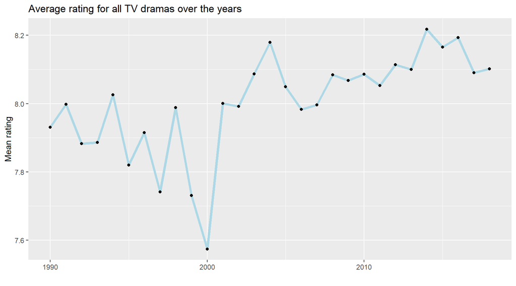

Histogram shows a normal distribution with a skewness to the left tail, mean and median are close,mean is used in the analysis.

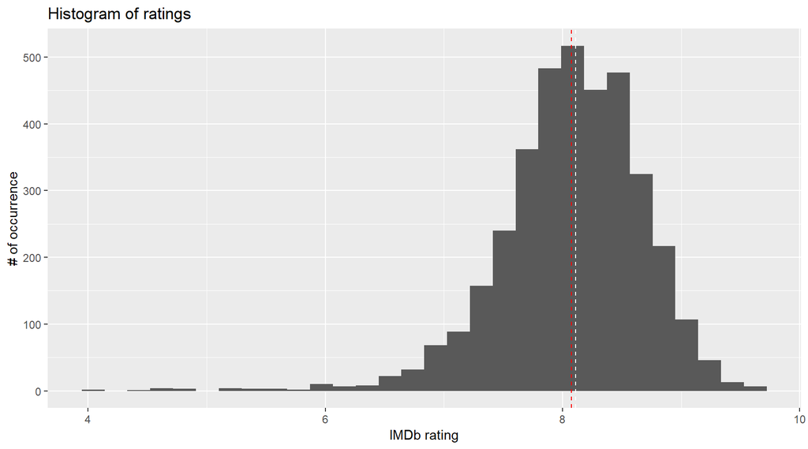

How did our taste change ovetime based on Average rating?.

Most genres show no significant change, except for animation which has seen a rise in interest from the beginning of this decade. Another notable mentions is, War movies being assosciated with drama is a somewhat new combination of genres.

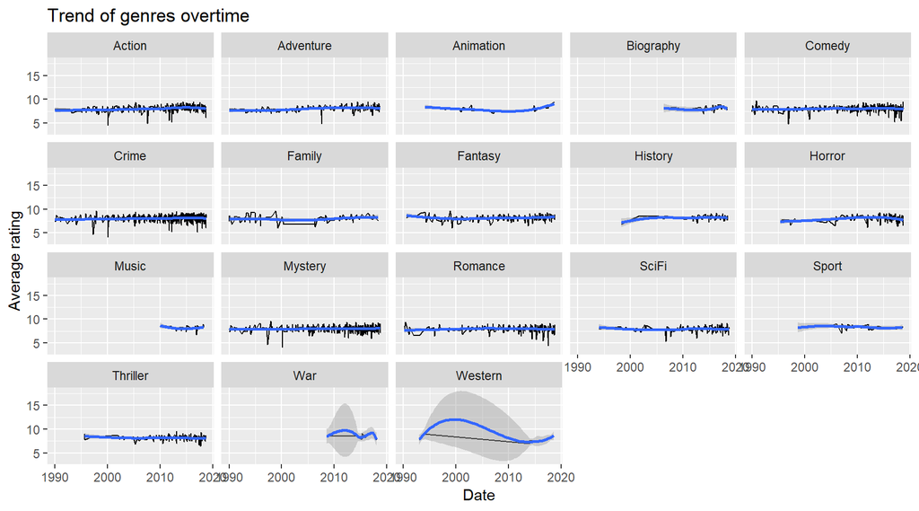

How many series is the industry releasing per genre overtime?

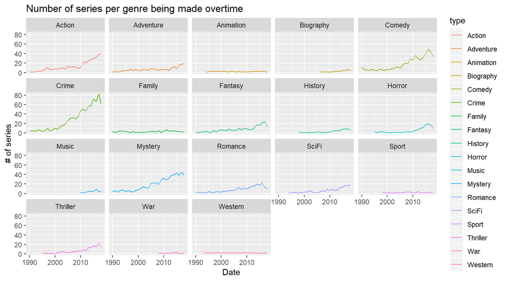

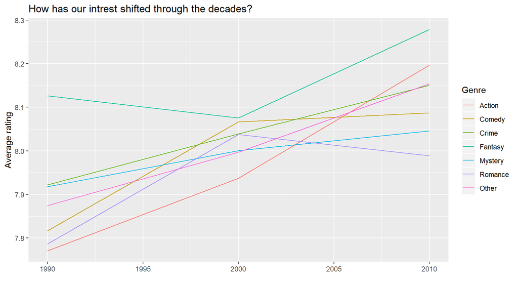

Looking for a long Drama series?.

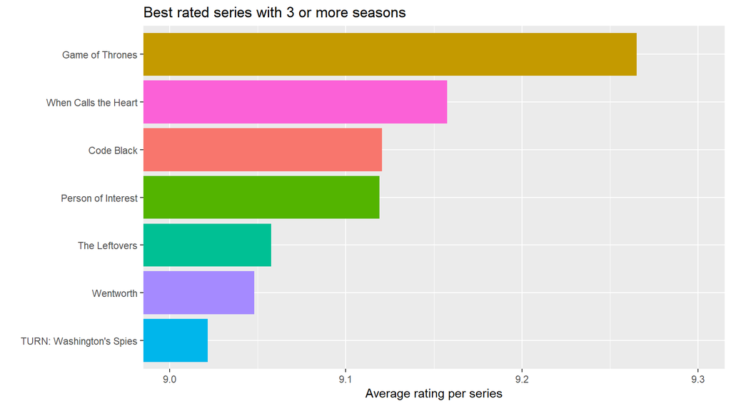

### Which had the best rating per season?

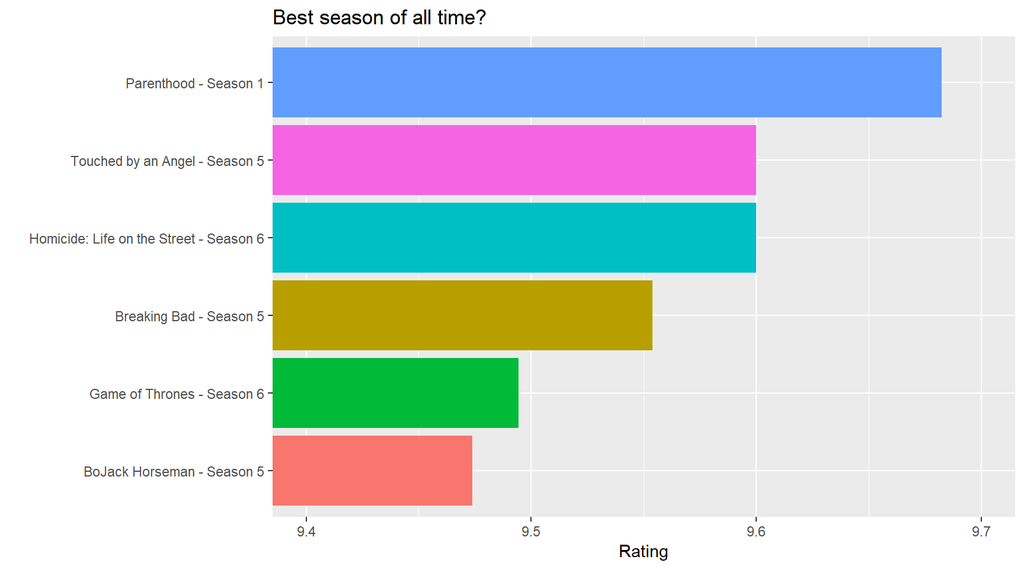

# Show survival

## Was the increase in ratings contributed to the interest of viewers overtime, or was it contributed to of experience of the producers on knowing when to cancel a bad series overtime?

Before 2000, what this graph shows is that a rating of “7-7.5” before 2000 had more than 60% chance of being renewed compared to a 33% chance after 2000, this could be contributed to the increase in competitiveness of series after 2000.

We can see that a rating of 8 and more decreased the chance of a second season before 2000, while it increased after 2000, this could be the increase in expertise of the industry in knowing viewer preferences.

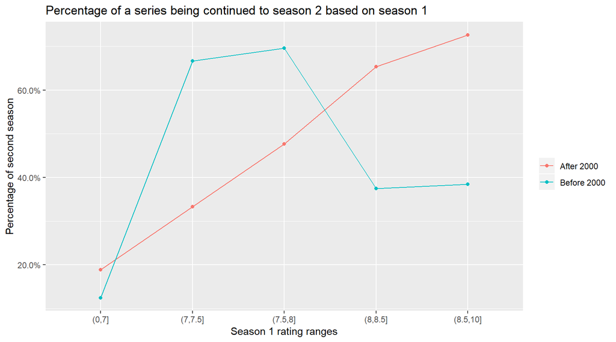

The model shows what we expected, a higher rated series in 1990 had a lower chance of being continued to season 2 than in 2018, this emphasizes the increase in expertise of producers overtime.

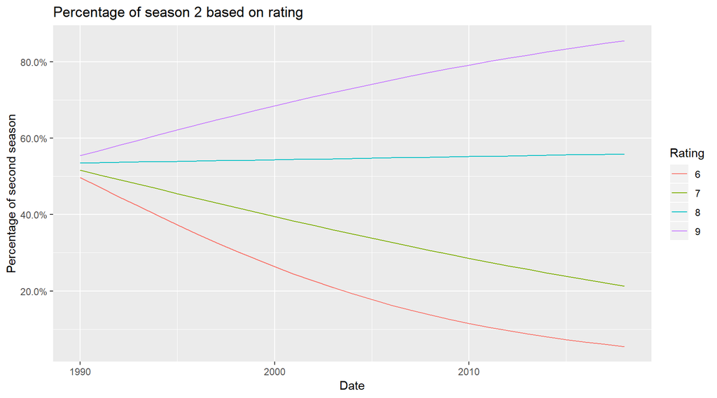